# Microarray_analysis

Teresa Coimbra

2022-10-12

# Analysis of microarray datasets - part 1

## Dataset 1

Effect of iodine on Arabidopsis thaliana (Col-0) trancriptome https://www.ncbi.nlm.nih.gov/geo/query/acc.cgi?acc=GSE157643 GEO Accession: GSE157643

This dataset was preprocessed, using rma normalization, and by removing rows that did not have a corresponding Gene symbol. Next, probes were selected in order to maintain the highest variance in data, by using the collapseRows funcion.

```r
WCmV <- read.csv("WCmV.csv", row.names=1)
```

Data has the expression information plus 2 columns containing the group of the probe, and the probe ID (selectedRowID):

```r
head(WCmV)
```

```
##                   group selectedRowID leaves_control leaves_KBr leaves_NaI
## 2-Cys Prx B 2-Cys Prx B     250733_at      10.763292  10.622084  10.488583
## 2A6                 2A6     264826_at       4.713803   4.677223   4.873451
## 4CL1               4CL1     256186_at       8.716197   8.561017   8.814306
## 4CL2               4CL2     258047_at       6.596805   6.097800   6.277624
## 4CL3               4CL3     261907_at       6.523082   6.450777   5.290736
## 4CL5               4CL5     258037_at       5.568948   5.821280   6.111289
##             leaves_KI roots_control roots_KBr roots_NaI  roots_KI
## 2-Cys Prx B 10.676408      6.358215  6.089101  6.362571  6.281704
## 2A6          4.560272      4.602391  4.744951  4.140262  4.019605
## 4CL1         8.404788     10.241758 10.535488 11.357603 11.366676
## 4CL2         6.259020      9.533979  9.733802  9.973290  9.786743
## 4CL3         5.699875      4.139735  4.208735  4.439832  4.298843
## 4CL5         5.762939      8.891087  9.190828  9.181160  9.037680
```

```r
dim(WCmV)
```

```
## [1] 21057    10
```

Subseting the expression data only:

```r
dfe <- WCmV[,3:10]
```

The limma package was studied and tested, however, since there is only one file for each treatment on the 2 different tissues (leaves and roots) it is not possible to obtain robust results (no replicates).

```r
lst.ks <- lapply(1:ncol(dfe), function(i)
    ks.test(dfe[, i], "pexp", 1.0/mean(dfe[, i])))
Dstat <- sapply(lst.ks, function(x) x$statistic)
Dstat
```

```
##         D         D         D         D         D         D         D         D
## 0.3757281 0.3699814 0.3691435 0.3756664 0.3666330 0.3698478 0.3685723 0.3658912
```

# ANOVA

Separating leaves and roots into two dataframes: df_leaves and df_roots

## Testing the interaction between treatment and tissue:

Y = u + Tissue*Treatment + error

```r
df_all <- data.frame(df_leaves, df_roots[,2:5])
df_all <- melt(df_all)
df_all[c("Tissue","Treatment")]<-str_split_fixed(df_all$variable,"_",2)
```

```r
colnames(df_all) <- c("ID","variable","Expression","Tissue","Treatment")
df_all[1:3,]
```

```
##            ID       variable Expression Tissue Treatment
## 1 2-Cys Prx B leaves_control  10.763292 leaves   control
## 2         2A6 leaves_control   4.713803 leaves   control
## 3        4CL1 leaves_control   8.716197 leaves   control
```

Stating the hypothesis:

Test whether there is an interaction on tissue and treatment affecting gene expression levels.

```r
anova1 <- aov(Expression ~ Treatment*Tissue, data = df_all)

summary(anova1)
```

```
##                      Df Sum Sq Mean Sq F value   Pr(>F)
## Treatment             3     73   24.45   5.134   0.0015 **
## Tissue                1    175  175.09  36.771 1.33e-09 ***
## Treatment:Tissue      3     42   13.95   2.930   0.0322 *
## Residuals        168448 802104    4.76
## ---
## Signif. codes:  0 '***' 0.001 '**' 0.01 '*' 0.05 '.' 0.1 ' ' 1
```

In the table above the “Treatment:Tissue” variable has a p-value=0.0322. This means there the interaction is significant and a source of variation on gene expression level. In fact, it is expected that there is a variation on expression levels on different plant tissues.

```r
tukey1<-TukeyHSD(anova1)
```

```r
tukey.plot.aov<-aov(Expression ~ Tissue:Treatment, data=df_all)
tukey.plot.test<-TukeyHSD(tukey.plot.aov)
```

```
## Found more than one class "simpleUnit" in cache; using the first, from namespace 'ggbio'
```

```
## Also defined by 'hexbin'
```

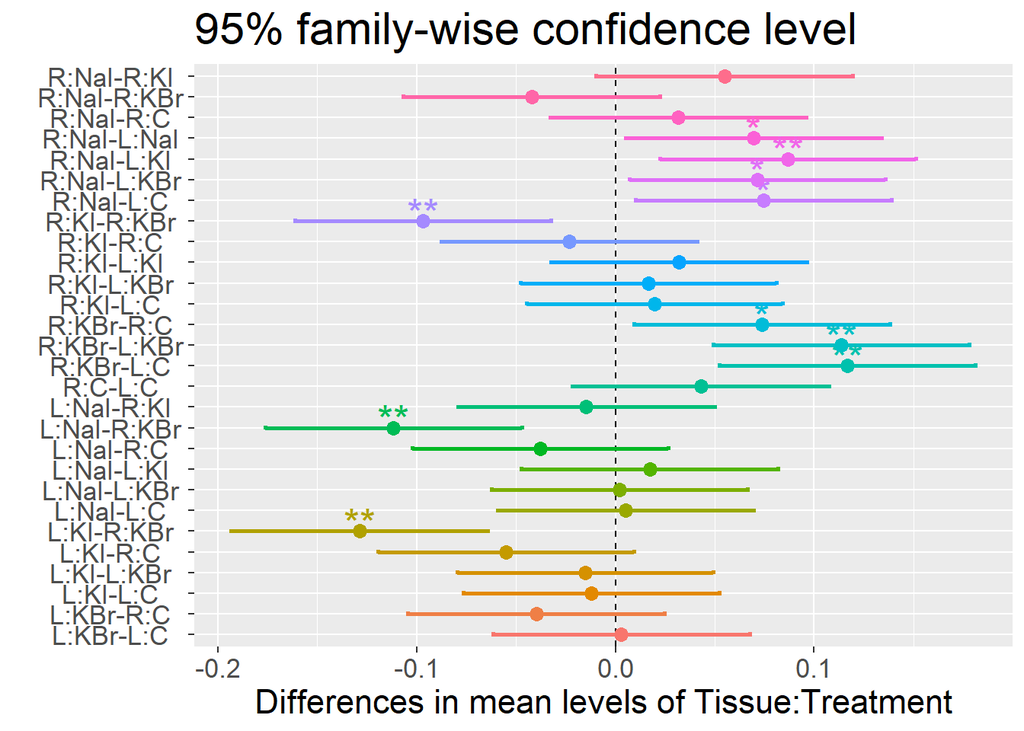

```r
ggHSD(tukey.plot.test)+
      theme(plot.title=element_text(size=rel(2)),
              axis.text.y=element_text(angle = 0, size=rel(1.5),hjust=0.5),
              axis.text.x=element_text(size=rel(1.5)),
              axis.title.x=element_text(size=rel(1.5)))
```

1. KBr:roots-control:leaves (p-value=0.0000011)
2. KBr:roots-KBr:leaves (p-value=0.0000025)
3. KBr:roots-KI:leaves (p-value=0.0000000)
4. NaI:roots-KI:leaves (p-value=0.0011947)
5. KBr:roots-NaI:leaves (p-value=0.0000042)
6. NaI:roots-control:leaves (p-value=0.0109511)
7. NaI:roots-KBr:leaves (p-value=0.0176926)
8. NaI:roots-NaI:leaves (p-value=0.0242985)
9. KBr:roots-control:roots (p-value=0.0122500)
10. KI:roots-KBr:roots (p-value=0.0001377)

The first 8 groups show significant differences in treatments in different tissues. The second group shows that there is a significant difference within the same treatment (KBr) between roots and leaves. Groups 9 and 10 show significant differences on the same tissue (roots) between treatments with KBr and the control treatment,and that KI and KBr have caused significant differences of expression in the roots. This can mean that KBr is causing significant differences in expression levels in the roots. It is not likely that this difference is attributed to the effect of KI since there are no differences detected here between this treatment and the control on the roots.

Other tests will be performed by conducting separate analysis on the leaves and roots.

## Testing only differences in treatment on Leaves:

```r
DFL <-melt(df_leaves)
head(DFL)
```

```
##            ID       variable     value
## 1 2-Cys Prx B leaves_control 10.763292
## 2         2A6 leaves_control  4.713803
## 3        4CL1 leaves_control  8.716197
## 4        4CL2 leaves_control  6.596805
## 5        4CL3 leaves_control  6.523082
## 6        4CL5 leaves_control  5.568948
```

```r
colnames(DFL)<-c("ID","Treatment","Expression")
DFL$Treatment <- gsub("leaves_","",DFL$Treatment)
head(DFL)
```

```
##            ID Treatment Expression
## 1 2-Cys Prx B   control  10.763292
## 2         2A6   control   4.713803
## 3        4CL1   control   8.716197
## 4        4CL2   control   6.596805
## 5        4CL3   control   6.523082
## 6        4CL5   control   5.568948
```

Stating the hypothesis: H0: The mean value of expression in the different treatments is the same H1: The mean value of expression is different between treatments.

```r
leaves_anova1 <- aov(Expression ~ Treatment, data = DFL)

summary(leaves_anova1)
```

```
##                Df Sum Sq Mean Sq F value Pr(>F)
## Treatment       3      4   1.254   0.266   0.85
## Residuals   84224 396400   4.706
```

There are 3 degrees of freedom (number of treatments-1). The sum of squares displays the total variation between the means of treatments and the overall mean. P-value = 0.85 (p-value>0.05), therefore, there are no significant differences between treatments in the leaves.

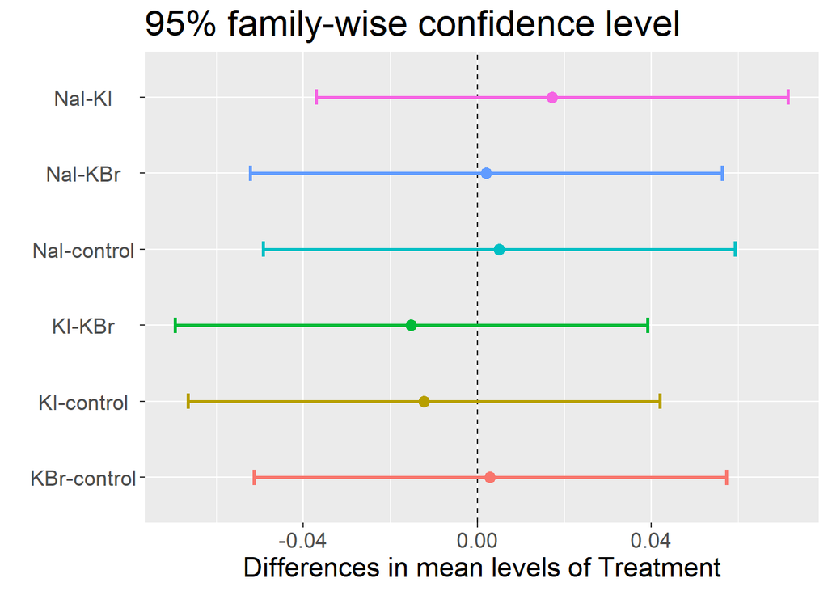

```r
tukey_leaves1<-TukeyHSD(leaves_anova1)
ggHSD(tukey_leaves1)+
      theme(plot.title=element_text(size=rel(2)),
              axis.text.y=element_text(angle = 0, size=rel(1.5),hjust=0.5),
              axis.text.x=element_text(size=rel(1.5)),
              axis.title.x=element_text(size=rel(1.5)))
```

Roots:

```r
DFR <-melt(df_roots)
head(DFR)
```

```
##            ID      variable     value
## 1 2-Cys Prx B roots_control  6.358215
## 2         2A6 roots_control  4.602391
## 3        4CL1 roots_control 10.241758
## 4        4CL2 roots_control  9.533979
## 5        4CL3 roots_control  4.139735
## 6        4CL5 roots_control  8.891087
```

```r
colnames(DFR)<-c("ID","Treatment","Expression")
DFR$Treatment <- gsub("roots_","",DFR$Treatment)
```

Stating the hypothesis: H0: The mean value of expression on roots in the different treatments is the same H1: The mean value of expression on roots is different between treatments.

```r
roots_anova1 <- aov(Expression ~ Treatment, data = DFR)

summary(roots_anova1)
```

```
##                Df Sum Sq Mean Sq F value   Pr(>F)
## Treatment       3    111   37.14   7.711 3.79e-05 ***
## Residuals   84224 405704    4.82
## ---
## Signif. codes:  0 '***' 0.001 '**' 0.01 '*' 0.05 '.' 0.1 ' ' 1
```

We can conclude that there is a significant difference on gene expression levels on the roots between the treatments (p-value<0.05).

As a post-hoc test, the Tukey’s Honestly Significant Difference (Tuckey’s HSD) test can be used to perform pairwise-comparisons between treatments, and therefore discover which groups are statistically different.

```r
tukey_roots1<-TukeyHSD(roots_anova1)

tukey_roots1
```

```
##   Tukey multiple comparisons of means
##     95% family-wise confidence level
##
## Fit: aov(formula = Expression ~ Treatment, data = DFR)
##
## $Treatment
##                    diff           lwr         upr     p adj
## KBr-control  0.07376995  0.0188192796  0.12872062 0.0031584
## KI-control  -0.02322454 -0.0781752081  0.03172613 0.6982522
## NaI-control  0.03155231 -0.0233983593  0.08650298 0.4526045
## KI-KBr      -0.09699449 -0.1519451554 -0.04204382 0.0000342
## NaI-KBr     -0.04221764 -0.0971683066  0.01273303 0.1979242
## NaI-KI       0.05477685 -0.0001738189  0.10972752 0.0510884
```

From the Tukey’s HSD test it is possible to observe that there are statistically significant differences (95% confidence) between: - roots treated with KBr and the control (p-value = 0.0031584) - roots treated with KI and KBr (p-value = 0.0000342)

These differences can be clearly observed in the following plot:

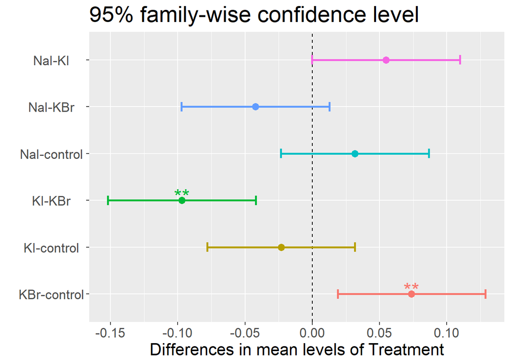

```r
ggHSD(tukey_roots1)+
      theme(plot.title=element_text(size=rel(2)),
              axis.text.y=element_text(angle = 0, size=rel(1.5),hjust=0.5),
              axis.text.x=element_text(size=rel(1.5)),
              axis.title.x=element_text(size=rel(1.5)))
```

# Testing a filter before ANOVA (filter then repeat)

Genes with constant values may not add relevant information.

# Using GWENA package

Transpose data:

```r
tdfe <- t(dfe)
```

Genes are now in columns, while samples are in rows:

```r
tdfe[1:8,1:5]
```

```
##                2-Cys Prx B      2A6      4CL1     4CL2     4CL3
## leaves_control   10.763292 4.713803  8.716197 6.596805 6.523082
## leaves_KBr       10.622084 4.677223  8.561017 6.097800 6.450777
## leaves_NaI       10.488583 4.873451  8.814306 6.277624 5.290736
## leaves_KI        10.676408 4.560272  8.404788 6.259020 5.699875
## roots_control     6.358215 4.602391 10.241758 9.533979 4.139735
## roots_KBr         6.089101 4.744951 10.535488 9.733802 4.208735
## roots_NaI         6.362571 4.140262 11.357603 9.973290 4.439832
## roots_KI          6.281704 4.019605 11.366676 9.786743 4.298843
```

Filter low variance data: Using this filtering, 14739 genes remain (6318 genes were removed).

```r
Exp_filter <- filter_low_var(tdfe, pct = 0.7, type = "median")

# Remaining number of genes
ncol(tdfe)
```

```
## [1] 21057
```

```r
ncol(Exp_filter)
```

```
## [1] 14739
```

```r
MEF <- melt(t(Exp_filter))
```

```r
MEF[c("Tissue","Treatment")]<-str_split_fixed(MEF$X2,"_",2)
MEF <- data.frame(MEF$X1,MEF$value,MEF$Tissue,MEF$Treatment)
colnames(MEF)<-c("ID","Expression","Tissue","Treatment")
```

```r
fanova <- aov(Expression ~ Treatment*Tissue, data = MEF)

summary(fanova)
```

```
##                      Df Sum Sq Mean Sq F value   Pr(>F)
## Treatment             3     94   31.32   9.638 2.34e-06 ***
## Tissue                1    173  172.76  53.166 3.08e-13 ***
## Treatment:Tissue      3     19    6.48   1.993    0.113
## Residuals        117904 383112    3.25
## ---
## Signif. codes:  0 '***' 0.001 '**' 0.01 '*' 0.05 '.' 0.1 ' ' 1
```

The interaction is no longer significative.

```r
tukey_f<-TukeyHSD(fanova)

tukey_f
```

```
##   Tukey multiple comparisons of means
##     95% family-wise confidence level
##
## Fit: aov(formula = Expression ~ Treatment * Tissue, data = MEF)
##
## $Treatment
##                    diff          lwr         upr     p adj
## KBr-control  0.05472272  0.016578036  0.09286740 0.0013048
## KI-control  -0.01606005 -0.054204726  0.02208464 0.7007837
## NaI-control  0.03691336 -0.001231321  0.07505804 0.0620704
## KI-KBr      -0.07078276 -0.108927443 -0.03263808 0.0000111
## NaI-KBr     -0.01780936 -0.055954038  0.02033532 0.6271755
## NaI-KI       0.05297341  0.014828725  0.09111809 0.0020408
##
## $Tissue
##                    diff        lwr       upr p adj
## roots-leaves 0.07655397 0.05597623 0.0971317     0
##
## $`Treatment:Tissue`
##                                       diff           lwr         upr     p adj
## KBr:leaves-control:leaves     0.0442249898 -0.0194176278  0.10786761 0.4107736
## KI:leaves-control:leaves      0.0021607784 -0.0614818391  0.06580340 1.0000000
## NaI:leaves-control:leaves     0.0572575121 -0.0063851055  0.12090013 0.1145097
## control:roots-control:leaves  0.0905875927  0.0269449751  0.15423021 0.0004259
## KBr:roots-control:leaves      0.1558080368  0.0921654192  0.21945065 0.0000000
## KI:roots-control:leaves       0.0563067237 -0.0073358939  0.11994934 0.1281348
## NaI:roots-control:leaves      0.1071568000  0.0435141825  0.17079942 0.0000092
## KI:leaves-KBr:leaves         -0.0420642114 -0.1057068289  0.02157841 0.4795523
## NaI:leaves-KBr:leaves         0.0130325223 -0.0506100953  0.07667514 0.9986164
## control:roots-KBr:leaves      0.0463626029 -0.0172800147  0.11000522 0.3467482
## KBr:roots-KBr:leaves          0.1115830470  0.0479404294  0.17522566 0.0000030
## KI:roots-KBr:leaves           0.0120817339 -0.0515608837  0.07572435 0.9991538
## NaI:roots-KBr:leaves          0.0629318102 -0.0007108073  0.12657443 0.0551727
## NaI:leaves-KI:leaves          0.0550967337 -0.0085458839  0.11873935 0.1472192
## control:roots-KI:leaves       0.0884268143  0.0247841967  0.15206943 0.0006690
## KBr:roots-KI:leaves           0.1536472584  0.0900046408  0.21728988 0.0000000
## KI:roots-KI:leaves            0.0541459452 -0.0094966723  0.11778856 0.1636386
## NaI:roots-KI:leaves           0.1049960216  0.0413534040  0.16863864 0.0000158
## control:roots-NaI:leaves      0.0333300806 -0.0303125370  0.09697270 0.7581943
## KBr:roots-NaI:leaves          0.0985505247  0.0349079072  0.16219314 0.0000732
## KI:roots-NaI:leaves          -0.0009507884 -0.0645934060  0.06269183 1.0000000
## NaI:roots-NaI:leaves          0.0498992880 -0.0137433296  0.11354191 0.2529240
## KBr:roots-control:roots       0.0652204441  0.0015778265  0.12886306 0.0399687
## KI:roots-control:roots       -0.0342808690 -0.0979234866  0.02936175 0.7305389
## NaI:roots-control:roots       0.0165692073 -0.0470734102  0.08021182 0.9937161
## KI:roots-KBr:roots           -0.0995013131 -0.1631439307 -0.03585870 0.0000587
## NaI:roots-KBr:roots          -0.0486512368 -0.1122938543  0.01499138 0.2841176
## NaI:roots-KI:roots            0.0508500764 -0.0127925412  0.11449269 0.2306496
```

```r
DFL2 <- melt(DFL2)
colnames(DFL2)<-c("ID","Treatment","Expression")
DFL2$Treatment <- gsub("leaves_","",DFL2$Treatment)
```

```r
leaves_anova2 <- aov(Expression ~ Treatment, data = DFL2)
summary(leaves_anova2)
```

```
##                Df Sum Sq Mean Sq F value  Pr(>F)
## Treatment       3     38  12.545   3.848 0.00913 **
## Residuals   58952 192214   3.261
## ---
## Signif. codes:  0 '***' 0.001 '**' 0.01 '*' 0.05 '.' 0.1 ' ' 1
```

```r
tukey_leaves2<-TukeyHSD(leaves_anova2)

tukey_leaves2
```

```
##   Tukey multiple comparisons of means
##     95% family-wise confidence level
##
## Fit: aov(formula = Expression ~ Treatment, data = DFL2)
##
## $Treatment
##                     diff          lwr        upr     p adj
## KBr-control  0.044224990 -0.009812298 0.09826228 0.1522299
## KI-control   0.002160778 -0.051876510 0.05619807 0.9996122
## NaI-control  0.057257512  0.003220224 0.11129480 0.0328651
## KI-KBr      -0.042064211 -0.096101500 0.01197308 0.1879834
## NaI-KBr      0.013032522 -0.041004766 0.06706981 0.9258580
## NaI-KI       0.055096734  0.001059446 0.10913402 0.0436796
```

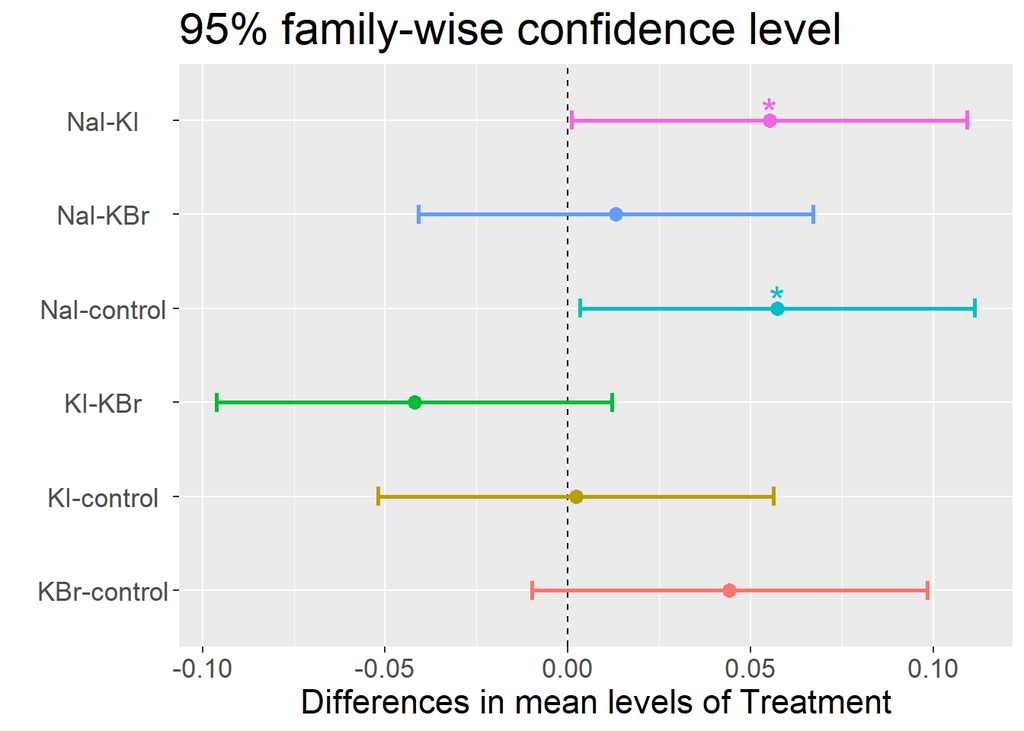

```r
ggHSD(tukey_leaves2)+
        theme(plot.title=element_text(size=rel(2)),
        axis.text.y=element_text(angle = 0, size=rel(1.5),hjust=0.5),
        axis.text.x=element_text(size=rel(1.5)),
        axis.title.x=element_text(size=rel(1.5)))
```

### Performing a second ANOVA test with roots data

```r
DFR2 <- melt(DFR2)
colnames(DFR2)<-c("ID","Treatment","Expression")
DFR2$Treatment <- gsub("roots_","",DFR2$Treatment)
```

```r
roots_anova2 <- aov(Expression ~ Treatment, data = DFR2)
summary(roots_anova2)
```

```
##                Df Sum Sq Mean Sq F value   Pr(>F)
## Treatment       3     76  25.249   7.797 3.35e-05 ***
## Residuals   58952 190898   3.238
## ---
## Signif. codes:  0 '***' 0.001 '**' 0.01 '*' 0.05 '.' 0.1 ' ' 1
```

```r
tukey_roots2<-TukeyHSD(roots_anova2)

tukey_roots2
```

```
##   Tukey multiple comparisons of means
##     95% family-wise confidence level
##
## Fit: aov(formula = Expression ~ Treatment, data = DFR2)
##
## $Treatment
##                    diff          lwr          upr     p adj
## KBr-control  0.06522044  0.011368442  0.119072446 0.0100614
## KI-control  -0.03428087 -0.088132871  0.019571133 0.3586345
## NaI-control  0.01656921 -0.037282794  0.070421209 0.8588375
## KI-KBr      -0.09950131 -0.153353315 -0.045649311 0.0000123
## NaI-KBr     -0.04865124 -0.102503239  0.005200765 0.0932744
## NaI-KI       0.05085008 -0.003001925  0.104702078 0.0722790
```

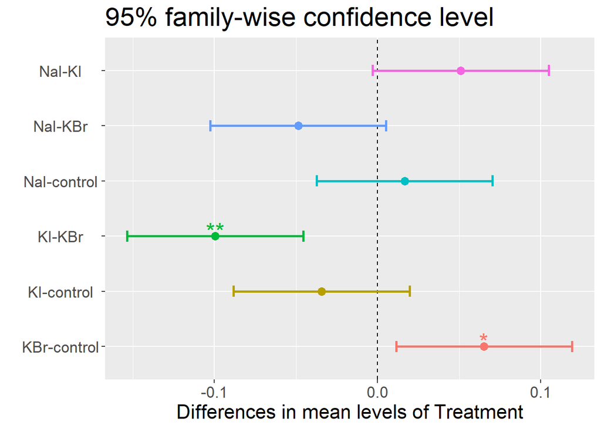

```r
ggHSD(tukey_roots2)+
        theme(plot.title=element_text(size=rel(2)),
        axis.text.y=element_text(angle = 0, size=rel(1.5),hjust=0.5),
        axis.text.x=element_text(size=rel(1.5)),
        axis.title.x=element_text(size=rel(1.5)))
```